# An introduction to ASCEND - Analysis of Single Cell Expression, Normalisation and Differential expression

#### Filtering by expression

The final step of filtering is to remove low-abundance genes. The average expression of genes can be reviewed on the average transcript count plots.

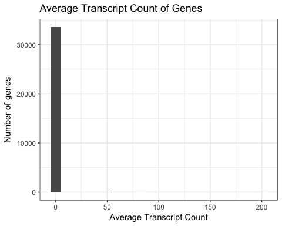

```r
print(raw.qc.plots$AverageGeneCount)
```

Due to the nature of single-cell RNASeq, many genes will have zero or near-zero expression. Have a closer look at the distribution with the Log2 and Log10 average transcript count plots.

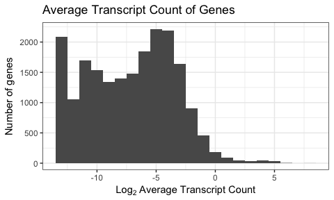

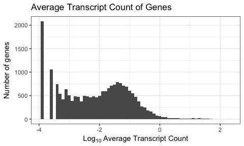

```r
print(raw.qc.plots$Log2AverageGeneCount)
print(raw.qc.plots$Log10AverageGeneCount)
```

Use `FilterByExpressedGenesPerCell` to remove genes that have zero or near-zero expression in at least a certain percentage of the cell population. We will use the value of 1% for this tutorial.

```r
aem.set <- FilterByExpressedGenesPerCell(aem.set, 0.01)
```

```
## [1] "Calculating control metrics..."
##
```

#### Filtering Review

Review the impact of filtering on the dataset by running `PlotGeneralQC` again. `ASCEND` has also kept track of the filtering process and has recorded which cells and genes were filtered from the dataset.

```
## [1] "Plotting Total Count and Library Size..."
## [1] "Plotting Average Counts..."
```

```
## [1] "Plotting Proportion of Control Histograms..."
## [1] "Using ggplot2 to plot Control Percentages..."
## [1] "Using ggplot2 to plot Library Sizes Per Sample..."
## [1] "Using ggplot2 to plot Top Genes Per Sample..."
## [1] "Using ggplot2 to plot Top Gene Expression..."
```

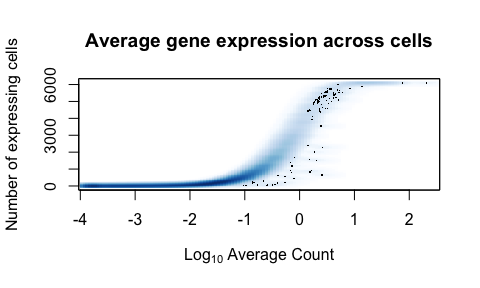

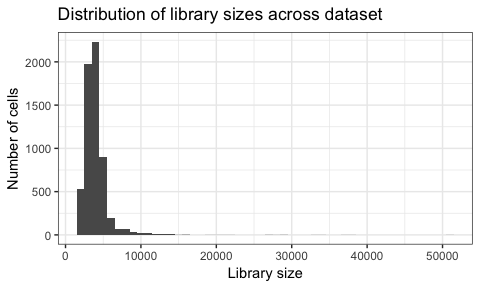

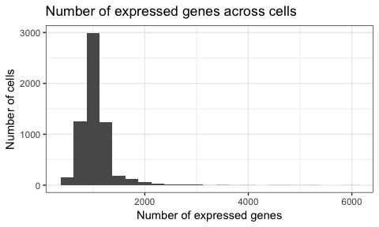

You can view the log with `DisplayLog`.

```r
DisplayLog(aem.set)
```

```
## $Filtering
## $Filtering$FilterByExpressedGenesPerCell
## named integer(0)
##
## $Filtering$FilteringList
## $Filtering$FilteringList$FilterByExpressedGenesPerCell
## [1] 0
##
##
##
## $FilteringLog
##   BarcodesFilteredByLibSize BarcodesFilteredByLowExpression
## 1                       389                             398
##   BarcodesFilteredByControls NumberOfBarcodesFilteredByMt
## 1                          2                          468
##   NumberOfBarcodesFilteredByRb
## 1                            0
##
## [1] "Filtering Log:"
##   BarcodesFilteredByLibSize BarcodesFilteredByLowExpression
## 1                       389                             398
##   BarcodesFilteredByControls NumberOfBarcodesFilteredByMt
## 1                          2                          468
##   NumberOfBarcodesFilteredByRb
## 1                            0
```

### Normalisation

Normalisation needs to be done at two levels - between batches and between cells.

The ASCEND package contains the following normalisation functions:

- NormaliseBatches: Normalise library sizes between batches.
- NormaliseByRLE: Normalise library sizes between cells by Relative Log Expression (RLE).
- scranNormalise: Normalise library sizes between cells using *scran*’s deconvolution method.

How you use these functions depends on the dataset.

#### NormaliseBatches

Normalisation between batches needs to be done prior to filtering.

For this tutorial - we do not need to use the `NormaliseBatches` as this dataset was prepared with Cell Ranger’s *aggr* pipeline. This pipeline uses a subsampling process to normalise between batches [(Zheng et al. 2017)](https://www.nature.com/articles/ncomms14049).

We do need to normalise between cells so we can use one of the following functions: `NormaliseByRLE` or `scranNormalise`.

#### NormaliseByRLE

In this method, each cell is considered as one library and assumes that most genes are not differentially expressed. It uses gene expression values higher than 0 to calculate the geometric means of a gene. The geometric mean is the mean of the expression of the gene across all cells (for cells where the gene is detected). Each gene has one geometric mean value for all cell. For each cell, the gene expression values are divided by the geometric means to get one normalisation factor for a gene in that cell. The median of all the normalisation factors for all genes in that cell is the normalisation factor for the cell. Post RLE normalisation, a gene with 0 expression still has 0 expression. A gene with expression higher than 0 will have an expression value equal the raw expression divided by the calculated normalization factor for the cell. As spike-ins affect library size, they need to be removed prior to normalisation.

This method is relatively quick and can be run on a desktop.

```r
norm.set <- NormaliseByRLE(aem.set)
```

```
## [1] "Calculating geometric means..."
## [1] "Calculating normalisation factors..."
## [1] "Normalising data..."
```

#### scranNormalise

This function is a wrapper for the deconvolution method by [Lun et al. 2015](https://bioconductor.org/packages/release/bioc/html/scater.html) that uses the [scran](https://f1000research.com/articles/5-2122/v2) and [scater](https://bioconductor.org/packages/release/bioc/html/scater.html) packages. This method takes into account the high proportion of zero counts in single-cell data and tackles the zero-inflation problem by applying a pooling strategy to calculate size-factors of each pool. The pooled size factors are then deconvoluted to infer the size factor for each cell, which are used scale the counts within that cell. The [scran vignette](https://bioconductor.org/packages/release/bioc/vignettes/scran/inst/doc/scran.html) explains the whole process in greater detail.

If the dataset contains less than 10,000 cells, `scranNormalise` will run `scran`’s `computeSumFactors` function with preset sizes of 40, 60, 80 and 100. For larger datasets, `scranNormalise` will run `quickCluster` before `computeSumFactors`.

This method is computationally intensive; we do not recommend running datasets larger than 5000 cells on a desktop machine. Datasets larger than 10,000 cells should be run on a HPC.

To ensure compatibility with `scran` and `scater`, the `AEMSet` needs to have mitochondrial and ribosomal genes as controls. The control list also needs to be formatted as follows:

```r
print(GetControls(aem.set))
```

```
## $Mt
##  [1] "MT-ND1"  "MT-ND2"  "MT-ND3"  "MT-ND4L" "MT-ND4"  "MT-ND5"  "MT-ND6"
##  [8] "MT-CYB"  "MT-CO1"  "MT-CO2"  "MT-CO3"  "MT-ATP6" "MT-ATP8" "MT-CYB"
##
## $Rb
##  [1] "RPSA"   "RPS2"   "RPS3"   "RPS3A"  "RPS4X"  "RPS5"   "RPS6"
##  [8] "RPS7"   "RPS8"   "RPS9"   "RPS10"  "RPS11"  "RPS12"  "RPS13"
## [15] "RPS14"  "RPS15"  "RPS15A" "RPS16"  "RPS17"  "RPS18"  "RPS19"
## [22] "RPS20"  "RPS21"  "RPS23"  "RPS24"  "RPS25"  "RPS26"  "RPS27"
## [29] "RPS27A" "RPS28"  "RPS29"  "RPL3"   "RPL4"   "RPL5"   "RPL6"
## [36] "RPL7"   "RPL7A"  "RPL8"   "RPL9"   "RPL10"  "RPL10A" "RPL11"
## [43] "RPL12"  "RPL13"  "RPL13A" "RPL14"  "RPL15"  "RPL17"  "RPL18"
## [50] "RPL18A" "RPL19"  "RPL21"  "RPL22"  "RPL23"  "RPL23A" "RPL24"
## [57] "RPL26"  "RPL27"  "RPL27A" "RPL28"  "RPL29"  "RPL30"  "RPL31"
## [64] "RPL32"  "RPL34"  "RPL35"  "RPL35A" "RPL36"  "RPL36A" "RPL37"
## [71] "RPL37A" "RPL38"  "RPL39"  "RPL41"  "RPLP0"  "RPLP1"  "RPLP2"
```

Run `scranNormalise` as follows:

```r
norm.set <- scranNormalise(aem.set)
```

#### Reviewing the normalisation process

`PlotNormQC` will generate a series of plots for the review of the normalisation process. This function can only be used if you have retained the un-normalised `AEMSet`.

```r
norm.qc <- PlotNormalisationQC(original = aem.set, normalised = norm.set, gene.list = c("GAPDH", "ACTB"))
```

```
## [1] "Retrieving data from AEMSets..."
## [1] "Plotting libsize histograms..."
## [1] "Plotting GAPDH expression..."
## [1] "Plotting ACTB expression..."
## [1] "Plotting gene expression box plots..."
## [1] "Plotting gene expression box plots..."
## [1] "Plots complete!"
```

The first set of graphs are library size histograms. The `NormaliseByRLE` method does not affect library size as drastically as the `scranNormalise` method. Instead, the changes are more apparent on a gene level.

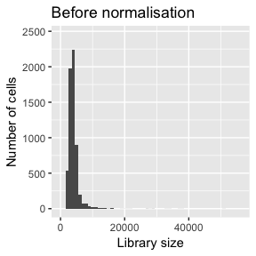

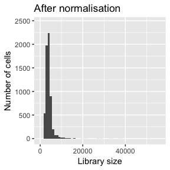

```r
print(norm.qc$Libsize$Original)
print(norm.qc$Libsize$Normalised)
```

The gene scatter plots show how expression has changed on a gene level. As GAPDH is highly expressed in this dataset, the effect of normalisation is not as apparent as it is for ACTB.

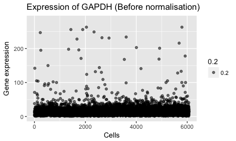

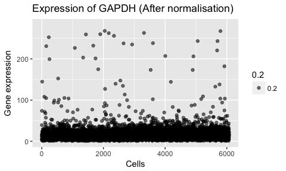

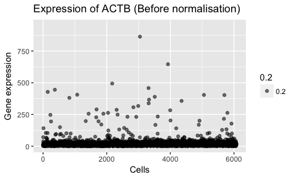

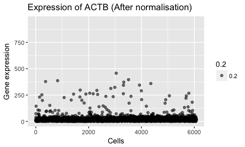

```r
print(norm.qc$GeneScatterPlots$GAPDH$Original)
print(norm.qc$GeneScatterPlots$GAPDH$Normalised)
print(norm.qc$GeneScatterPlots$ACTB$Original)
print(norm.qc$GeneScatterPlots$ACTB$Normalised)
```

The changes to overall gene expression can also be reviewed on gene expression boxplots.

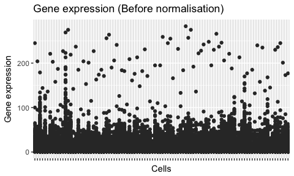

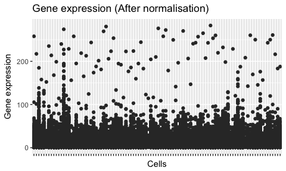

```r
print(norm.qc$GeneExpressionBoxplot$Original)
print(norm.qc$GeneExpressionBoxplot$Normalised)
```

### Control Removal

The plot generated by `PlotTopExpression` show ribosomal genes dominate the list of the most-expressed genes.

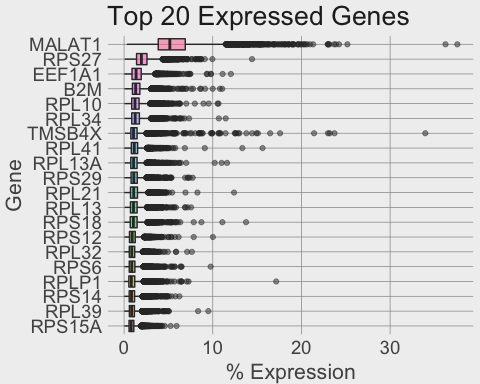

```r
top.20.plot <- PlotTopGeneExpression(aem.set, n = 20, controls = TRUE)
print(top.20.plot)
```

As we are interested in the expression of non-control genes, we will need to remove the controls from the dataset. This can be done with the `ExcludeControl` function.

```r
aem.set <- ExcludeControl(aem.set, "Mt")
```

```
## [1] "Calculating control metrics..."
##
```

```r
aem.set <- ExcludeControl(aem.set, "Rb")
```

```
## [1] "Calculating control metrics..."
##
```

Now that the control genes have been removed, the plot reveals many other genes of interest.

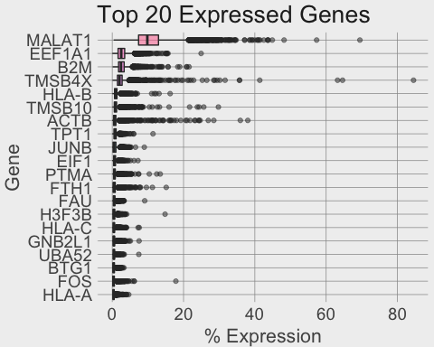

```r
top.20.plot <- PlotTopGeneExpression(aem.set, n = 20, controls = TRUE)
print(top.20.plot)
```

### Dimension Reduction

We have filtered our dataset down to 6100 cells and 33604 genes. We can reduce this dataset further by using *Principal Component Analysis (PCA)* to identify genes that are major contributors to variation.

```r
aem.set <- RunPCA(aem.set)
```

```
## [1] "Retrieving data..."
## [1] "Calculating variance..."
## [1] "Computing PCA values..."
## [1] "PCA complete! Returning object..."
```

PlotPCAVariance` generates what is known as a *scree plot*, which depicts what percentage each PC contributes to the total variance of the data. This will help determine how many PCs the dataset should be reduced to.

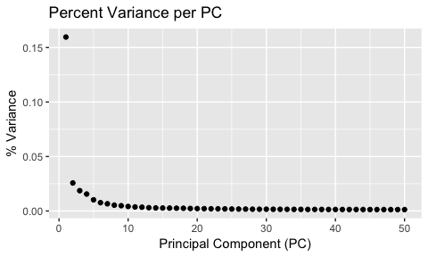

```r
pca.variance <- PlotPCAVariance(aem.set, 50)
print(pca.variance)
```

The scree plot shows most of the variance is due to the top 20 PCs. Reduce the dataset to 20 PCs with the `ReduceDimensions` function.

```r
aem.set <- ReduceDimensions(aem.set, 20)
```

### Clustering

Clustering can be done on the original expression matrix or the PCA-transformed matrix, which is the preferred input. Use `FindOptimalClusters` to identify clusters.

```r
aem.set <- FindOptimalClusters(aem.set)
```

```
## [1] "Performing unsupervised clustering..."
## [1] "Generating clusters by running dynamicTreeCut at different heights..."
## [1] "Calculating rand indices..."
## [1] "Calculating stability values..."
## [1] "Aggregating data..."
##
##
## [1] "Finding optimal number of clusters..."
## [1] "Optimal number of clusters found! Returning output..."
```

The `FindOptimalClusters` function generates a distance matrix based on the input and from this, builds a dendrogram. This dendrogram is then cut with the `DynamicTreeCut` algorithm to select clusters from the dendrogram based on the shape and size of the branches. This is repeated again, but this time with the tree-height parameter set to 40 values ranging from 0.025 (the bottom of the tree) to 1 (the top of the tree).

The `PlotStabilityDendro` generates a plot that represents this part of the process. In addition to the dendrogram, it generates the distribution of clusters across the 40 cut heights.

```
## $mar
## [1] 1 5 0 1
```

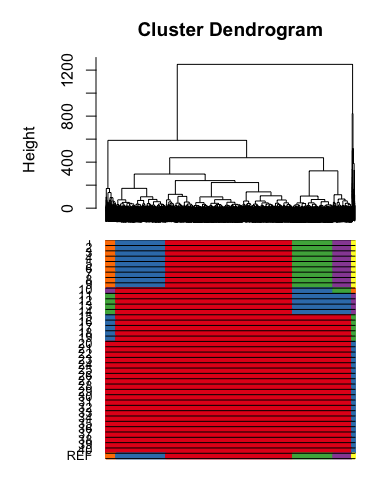

```r
PlotStabilityDendro(aem.set)
```

The clustering results are then compared quantitatively using rand indices, which calculates every pair of cells being in the same cluster or not. It is used as an indicator of the stability of a clustering result. If a rand index is stable across multiple tree-height values, this indicates the tree-height produces the most stable clustering result.

This information is shown on a plot generated by the `PlotStability` function.

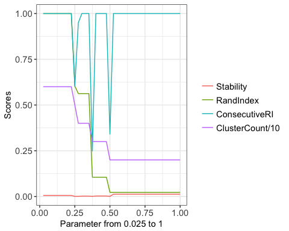

```r
PlotStability(aem.set)
```

The rand index is stable in 50% of tree-cut heights that correspond to the lowest number of clusters. Therefore, the optimal number of clusters is 2.

The `PlotDendrogram` function generates a dendrogram that depicts each cluster and its members.

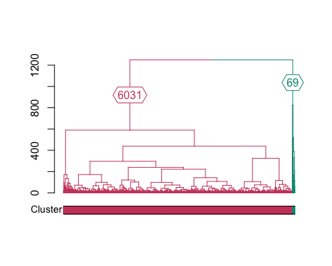

```r
PlotDendrogram(aem.set)
```

### Differential Expression

This package uses `DESeq` to perform differential expression, and can be done with or without clustering. Each cell needs to be assigned one of two conditions; for this tutorial, we will use batch information and clustering information. This step is computationally intensive for larger datasets.

#### Differential expression by condition

The `RunDiffExpression` function requires an `AEMSet`, two conditions and a list of cells and their associated condition.

We already have this condition list – batch information, which we can retrieve from the `AEMSet`. The conditions are therefore “1” and “2”.

```r
batch.info <- GetBatchInfo(aem.set)
batch.de.result <- RunDiffExpression(aem.set, condition.a = "1", condition.b = "2", condition.list = batch.info)
```

```
## [1] "Verifying input..."
## [1] "Input is acceptable. Verification complete!"
## [1] "Processing expression matrix..."
## [1] "Rounding expression matrix values..."
## [1] "Chunking matrix..."
## [1] "Chunking expression matrix by rows..."
```

```
## [1] "Running differential expression on 1 vs 2"
## [1] "Running DESeq..."
##
##
## [1] "Differential expression complete!"
## [1] "Returning values..."
## [1] "Combining DE results..."
## [1] "Adjusting fold change values..."
## [1] "Condition: 1 vs 2 complete!"
```

The results are sorted in ascending order, based on the p-value. The fold change values have been adjusted; they represent absolute fold change.

```r
batch.de.result[1:10,]
```

```
##             id baseMean baseMeanA baseMeanB  foldChange log2FoldChange
## 13884    IGLC2 3.582564  1.040016  5.582940 114.5286904      6.8395652
## 12405     KLF2 3.289997  4.733949  2.153953   0.3090436     -1.6941176
## 5345     IGHG2 1.361221  1.005332  1.641221 120.2617111      6.9100336
## 17800   SNHG25 1.922533  1.611512  2.167233   1.9087662      0.9326404
## 15865  IGLV3-1 1.325466  1.005408  1.577275 106.7477183      6.7380614
## 7715      NME2 1.528534  1.765674  1.341962   0.4466165     -1.1628915
## 4959     CMPK1 1.659115  1.892131  1.475788   0.5333162     -0.9069369
## 11654 IGLV2-11 1.254022  1.004246  1.450536 106.1113210      6.7294348
## 14867    EIF4B 1.731301  1.955957  1.554550   0.5800999     -0.7856268
## 1790     CSDE1 1.658735  1.877595  1.486545   0.5544071     -0.8509825
##                pval          padj
## 13884  0.000000e+00  0.000000e+00
## 12405 3.007008e-317 3.124281e-314
## 5345   1.461420e-61  1.518415e-58
## 17800  5.965262e-55  6.197908e-52
## 15865  4.794942e-51  4.981945e-48
## 7715   3.086580e-39  3.206957e-36
## 4959   3.212228e-35  3.337505e-32
## 11654  5.462828e-33  2.837939e-30
## 14867  7.038399e-32  7.312896e-29
## 1790   1.416004e-31  1.471228e-28
```

#### Differential expression by cluster comparison

`RunClusterDiffExpression` compares each cluster against other clusters. This function returns a list of differential expression results.

```r
cluster.de.result <- RunClusterDiffExpression(aem.set)
```

```
## [1] "Verifying input..."
## [1] "Input is acceptable. Verification complete!"
## [1] "Processing expression matrix..."
## [1] "Rounding expression matrix values..."
## [1] "Chunking matrix..."
## [1] "Chunking expression matrix by rows..."
```

```
## [1] "Running differential expression on 1 vs 2"
## [1] "Running DESeq..."
##
##
## [1] "Differential expression complete!"
## [1] "Returning values..."
## [1] "Combining DE results..."
## [1] "Adjusting fold change values..."
## [1] "Condition: 1 vs 2 complete!"
```

As there are only two clusters, only one comparison was made.

```r
cluster.de.result$`1vs2`[1:10,]
```

```
##             id baseMean baseMeanA baseMeanB foldChange log2FoldChange
## 176    HLA-DRA 1.795512  1.093101  63.19037  667.99173       9.383686
## 5799      CST3 1.547161  1.036932  46.14419 1222.37319      10.255469
## 7236      CD74 3.474389  2.124456 121.46636  107.13303       6.743260
## 8753  HLA-DPA1 1.683350  1.184727  45.26589  239.62890       7.904658
## 10112 HLA-DPB1 1.732929  1.248455  44.07883  173.38700       7.437852
## 13255 HLA-DRB1 1.550804  1.137274  37.69573  267.31700       8.062408
## 13884    IGLC2 3.582564  1.116080 219.16757 1879.46251      10.876104
## 14547    ACTG1 5.173555  4.583943  56.70909   15.54408       3.958293
## 5631     GAPDH 4.287836  3.790598  47.74931   16.75243       4.066299
## 15256      VIM 4.088735  3.659136  41.63820   15.28248       3.933807
##                pval          padj
## 176    0.000000e+00  0.000000e+00
## 5799   0.000000e+00  0.000000e+00
## 7236   0.000000e+00  0.000000e+00
## 8753   0.000000e+00  0.000000e+00
## 10112  0.000000e+00  0.000000e+00
## 13255  0.000000e+00  0.000000e+00
## 13884  0.000000e+00  0.000000e+00
## 14547  0.000000e+00  0.000000e+00
## 5631  3.886118e-281 2.018838e-278
## 15256 1.115881e-273 1.159401e-270
```

## Visualising data with ASCEND

`ASCEND` provides functions for generating PCA, TSNE and MDS plots that can be supplied with a condition list. The conditions can be of clustering results, batch information or the expression of specific genes.

#### Generating a condition list

The function `MakeGeneCondition` generates a condition list, labelling if a cell is expressing the selected gene, or not. This can be used to highlight cells that are expressing genes on plots generated by the `ASCEND` package.

We will label cells that are expressing the IGLC2 transcript.

```r
condition.list <- MakeGeneCondition(aem.set, "IGLC2")
```

#### PlotPCA

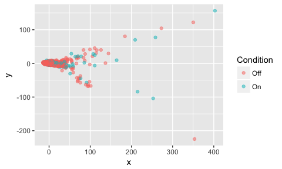

```r
pca.plot <- PlotPCA(aem.set, condition.list = condition.list)
print(pca.plot)
```

#### PlotTSNE

```r
tsne.plot <- PlotTSNE(aem.set, PCA = TRUE, condition.list = condition.list)
```

```
## [1] "Running Rtsne..."
## [1] "Rtsne complete! Returning matrix..."
```

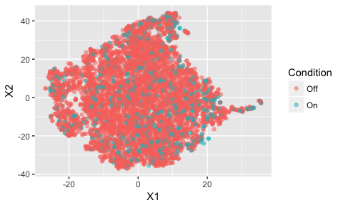

```r
print(tsne.plot)
```

#### PlotMDS

```r
mds.plot <- PlotMDS(aem.set, PCA = FALSE, condition.list = condition.list)
```

```
## [1] "Calculating distance matrix from expression data..."
## [1] "Running cmdscale..."
## [1] "Cmdscale complete! Processing scaled data..."
## [1] "Generating MDS plot..."
```

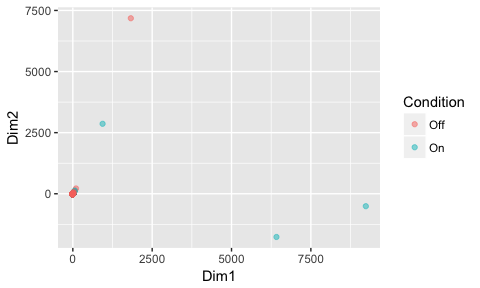

```r
print(mds.plot)
```

## References

Lun ATL, McCarthy DJ and Marioni JC. A step-by-step workflow for low-level analysis of single-cell RNA-seq data with Bioconductor [version 2; referees: 3 approved, 2 approved with reservations]. F1000Research 2016, 5:2122 (doi: 10.12688/f1000research.9501.2)

Zheng, G. X. Y. et al. Massively parallel digital transcriptional profiling of single cells. Nat. Commun. 8, 14049 doi: 10.1038/ncomms14049 (2017).

McCarthy DJ, Campbell KR, Lun ATL and Wills QF (2017). “Scater: pre-processing, quality control, normalisation and visualisation of single-cell RNA-seq data in R.” Bioinformatics, 14 Jan. doi: 10.1093/bioinformatics/btw777, http://dx.doi.org/10.1093/bioinformatics/btw777.